# Model predykcji zachorowań na raka piersi w Polsce

Patrycja Matys, Jan Rosa, Krzysztof Rutkowski, Magda Sobiczewska

17 czerwca 2016

# Wprowadzenie

Celem trzeciej fazy było stworzenie modelu, który najlepiej dokona predykcji liczby zachorowań na raka piersi w Polsce na następny rok, tj. 2013 w podziale na powiat, płeć i grupę wiekową. Predykcji dokonaliśmy, bazując na danych zawierających liczbę przypadków raka piersi w Polsce w latach 2010, 2011, 2012 z podziałem na płeć, 6 grup wiekowych, fazę choroby, kod TERYT/powiat oraz województwo. Korzystając z analiz dokonanych w poprzednich fazach, uznaliśmy, że dodatkowo wykorzystamy dane z Banku Danych Lokalnych GUS - dane te opisują czynniki mogące wpływać na odsetek zachorowań.

## Przygotowanie danych

Do predykcji przygotowaliśmy dane dotyczące powiatów, gdzie zmienną objaśnianą jest znormalizowany (przez liczbę osób w powiecie) **odsetek chorych na raka piersi**, zaś zmiennymi objaśniającymi są czynniki wymienione w częsci poświęconej metodologii. Poniższa tabela przedstawia omawiane zmienne:

```r
kable(head(y11[,1:6]))
```

| TERYT4 | GENDER | AGE_GROUP | PYLY | GAZY | GESTOSC |
| --- | --- | --- | --- | --- | --- |
| 201 | K | 1 | 0.0424333 | 35.182004 | 69.00000 |
| 202 | K | 1 | 0.0466267 | 54.059151 | 221.00000 |
| 203 | K | 1 | 0.3212933 | 3145.680211 | 204.00000 |
| 204 | K | 1 | 0.0298133 | 7.219061 | 50.00000 |
| 205 | K | 1 | 0.0429533 | 42.809278 | 90.33333 |
| 206 | K | 1 | 0.0786833 | 71.919724 | 104.00000 |

```r
kable(head(y11[,7:12]))
```

| URBANIZACJA | ZAGROZENIA | ZIELONE | LICZBA_ZACHOROWAN | Motytly | Fotytly |
| --- | --- | --- | --- | --- | --- |
| 0.0424333 | 611.00000 | 611.00000 | 0.0028652 | 0.1593844 | 0.1639549 |
| 0.0466267 | 577.66667 | 577.66667 | 0.0028056 | 0.1593844 | 0.1639549 |
| 0.3212933 | 4923.00000 | 4923.00000 | 0.0024947 | 0.1593844 | 0.1639549 |
| 0.0298133 | 90.33333 | 90.33333 | 0.0022683 | 0.1593844 | 0.1639549 |
| 0.0429533 | 713.33333 | 713.33333 | 0.0030594 | 0.1593844 | 0.1639549 |
| 0.0786833 | 310.66667 | 310.66667 | 0.0023898 | 0.1593844 | 0.1639549 |

```r
kable(head(y11[,13:18]))
```

| Malkohol | Falkohol | zsrednia.y | nsrednia.y | zm_dec.x | opoznienie |
| --- | --- | --- | --- | --- | --- |
| 0.1030992 | 0.0133333 | 4.1e-06 | 3.1e-06 | 0.0000647 | 6.47e-05 |
| 0.1030992 | 0.0133333 | 4.1e-06 | 3.1e-06 | 0.0000368 | 5.52e-05 |
| 0.1030992 | 0.0133333 | 4.1e-06 | 3.1e-06 | 0.0001296 | 8.64e-05 |
| 0.1030992 | 0.0133333 | 4.1e-06 | 3.1e-06 | 0.0000548 | 5.48e-05 |
| 0.1030992 | 0.0133333 | 4.1e-06 | 3.1e-06 | 0.0002279 | 1.14e-04 |
| 0.1030992 | 0.0133333 | 4.1e-06 | 3.1e-06 | 0.0001791 | 2.98e-05 |

## Sposób predykcji

Zdoloność predykcyjną modeli zbadaliśmy, estymując model na podstawie danych z **2011** roku, a następnie porównujac predykcję modelu na **2012** roku z rzeczywistymi wartościami.Optymalne parmetry dobieraliśmy za pomocą przeszukiwania parametrów i ewaluacji modelu za pomocą 10-krotnej kroswalidacji. Za kryterium obraliśmy błąd RMSE. Wyniki we wszystkich tabelach zostały pomnożone przez 10<sup>5</sup>.

# Użyte modele

Użyliśmy następujących metod:

- regresja liniowa
- gradient boosting
- random forest
- knn
- SVM

Jak się poniżej okaże, najlepiej sprawdziły się **regresja liniowa z zestawem zmiennych wybranych na podstawie kryterium BIC** oraz **gradient boosting z selekcją atrybutów**. Wybór najlepszych modeli przedstawiamy poniżej.

## Metodologia i wybór czynników

Na podstawie literatury przedmiotu, w poprzedniej fazie zauważyliśmy, że ważne są następujące czynniki:

- wiek
- płeć
- stężenie szkodliwych pyłów
- stężenie szkodliwych gazów
- urbanizacja
- gęstość zaludnienia

W trzeciej fazie postanowiliśmy dodać także czynniki:

- spożycie alkoholu wśród kobiet (dane dla województw)
- spożycie alkoholu wśród mężczyzn (dane dla województw)
- otyłość wśród kobiet (dane dla województw)
- otyłość wśród mężczyzn (dane dla województw)
- liczbę osób zarejestrowanych w poradniach psychologicznych (o zaburzeniach niealkoholowych i nieschizofrenicznych)
- liczbę osób z zaburzeniami psychicznymi (dane dla województw)
- liczbę osób chorych w poprzednim okresie

Za jedne z najważniejszych przyczyn nowotworu złośliwego piersi jest uznawane spożycie alkoholu oraz otyłość. Z tego powodu dodaliśmy pierwsze cztery czynniki. Za bardzo ważny determinant uznawany jest również wysoki poziom stresu, który przybliżać mają zmienne opisujące liczbę osób z problemami psychicznymi.

## Modele liniowe

W pierwszej kolejności oszacowaliśmy i przetestowaliśmy modele linowe. Moc predykcyjną przetestowaliśmy opisaną wyżej metodą.

Z modeli linowych na początku oszacowaliśmy zwykły model regresji. W zbiorze zmiennych objaśnianych znalazły się wszystkie rozważane przez nas zmienne, a także interakcje między wiekiem a urbanizacją. *Pierwszy* model wykorzystywał wszystkie zmienne, *drugi* czynniki wybrane na podstawie kryterium BIC. Otrzymano następujące modele:

```
##
## Call:
## lm(formula = zm_dec.x ~ GAZY + GESTOSC + ZIELONE + URBANIZACJA +
##     ZAGROZENIA + PYLY + GENDER * Fotytly * URBANIZACJA + GENDER *
##     Falkohol * URBANIZACJA + GENDER * Motytly + GENDER * Malkohol +
##     URBANIZACJA + as.factor(AGE_GROUP) * URBANIZACJA + nsrednia.y +
##     zsrednia.y + nsrednia.y * URBANIZACJA + opoznienie, data = y11)
##
## Residuals:
##        Min         1Q     Median         3Q        Max
## -2.886e-04 -4.333e-05 -5.760e-06  3.718e-05  4.204e-04
##
## Coefficients: (2 not defined because of singularities)
##                                     Estimate Std. Error t value Pr(>|t|)
## (Intercept)                        4.740e-06  3.832e-05   0.124  0.90157
## GAZY                               1.875e-10  2.541e-10   0.738  0.46073
## GESTOSC                            1.294e-08  3.240e-09   3.994 6.74e-05
## ZIELONE                            1.915e-09  1.213e-09   1.578  0.11478
## URBANIZACJA                        1.087e-05  2.244e-05   0.484  0.62812
## ZAGROZENIA                                NA         NA      NA       NA
## PYLY                                      NA         NA      NA       NA
## GENDERM                            2.518e-04  2.292e-04   1.099  0.27200
## Fotytly                            1.383e-04  2.173e-04   0.636  0.52458
## Falkohol                           9.254e-04  7.443e-04   1.243  0.21389
## Motytly                            2.918e-04  1.105e-04   2.641  0.00833
## Malkohol                          -2.039e-07  1.584e-04  -0.001  0.99897
## as.factor(AGE_GROUP)2              7.035e-05  6.641e-06  10.595  < 2e-16
## as.factor(AGE_GROUP)3              1.388e-04  7.173e-06  19.347  < 2e-16
## as.factor(AGE_GROUP)4              5.201e-05  6.249e-06   8.323  < 2e-16
## as.factor(AGE_GROUP)5              3.643e-06  6.166e-06   0.591  0.55468
## as.factor(AGE_GROUP)6             -5.901e-05  8.198e-06  -7.198 8.65e-13
## nsrednia.y                         6.940e-01  6.954e-01   0.998  0.31843
## zsrednia.y                        -2.640e+00  9.403e-01  -2.807  0.00504
## opoznienie                         2.352e-01  2.258e-02  10.417  < 2e-16
## GENDERM:Fotytly                   -1.869e-03  1.354e-03  -1.381  0.16757
## URBANIZACJA:GENDERM               -1.186e-04  9.464e-05  -1.253  0.21041
## URBANIZACJA:Fotytly               -7.289e-05  1.517e-04  -0.480  0.63094
## GENDERM:Falkohol                  -2.271e-03  3.247e-03  -0.700  0.48430
## URBANIZACJA:Falkohol              -2.373e-04  1.940e-04  -1.223  0.22136
## GENDERM:Motytly                   -8.891e-04  5.004e-04  -1.777  0.07575
```

[output cut: 37 more lines]

```
## URBANIZACJA:as.factor(AGE_GROUP)2 *
## URBANIZACJA:as.factor(AGE_GROUP)3 ***
## URBANIZACJA:as.factor(AGE_GROUP)4 *
## URBANIZACJA:as.factor(AGE_GROUP)5
## URBANIZACJA:as.factor(AGE_GROUP)6
## URBANIZACJA:nsrednia.y
## URBANIZACJA:GENDERM:Fotytly
## URBANIZACJA:GENDERM:Falkohol
## ---
## Signif. codes:  0 '***' 0.001 '**' 0.01 '*' 0.05 '.' 0.1 ' ' 1
##
## Residual standard error: 7.483e-05 on 1957 degrees of freedom
##   (327 observations deleted due to missingness)
## Multiple R-squared:  0.589,  Adjusted R-squared:  0.5823
## F-statistic: 87.65 on 32 and 1957 DF,  p-value: < 2.2e-16
```

```
##
## Call:
## lm(formula = zm_dec.x ~ GESTOSC + URBANIZACJA + GENDER + Falkohol +
##     Motytly + as.factor(AGE_GROUP) + zsrednia.y + opoznienie +
##     URBANIZACJA:GENDER + URBANIZACJA:Falkohol + GENDER:Motytly +
##     URBANIZACJA:as.factor(AGE_GROUP), data = y11)
##
## Residuals:
##        Min         1Q     Median         3Q        Max
## -2.889e-04 -4.424e-05 -4.950e-06  3.759e-05  4.192e-04
##
## Coefficients:
##                                     Estimate Std. Error t value Pr(>|t|)
## (Intercept)                        2.872e-05  1.765e-05   1.627  0.10388
## GESTOSC                            1.430e-08  2.884e-09   4.961 7.63e-07
## URBANIZACJA                        1.486e-06  2.844e-06   0.523  0.60123
## GENDERM                            1.995e-05  6.658e-05   0.300  0.76452
## Falkohol                           1.134e-03  3.860e-04   2.937  0.00335
## Motytly                            2.815e-04  1.078e-04   2.610  0.00912
## as.factor(AGE_GROUP)2              7.042e-05  6.619e-06  10.639  < 2e-16
## as.factor(AGE_GROUP)3              1.389e-04  7.138e-06  19.460  < 2e-16
## as.factor(AGE_GROUP)4              5.188e-05  6.236e-06   8.319  < 2e-16
## as.factor(AGE_GROUP)5              3.543e-06  6.156e-06   0.576  0.56498
## as.factor(AGE_GROUP)6             -5.907e-05  8.185e-06  -7.217 7.57e-13
## zsrednia.y                        -2.389e+00  7.887e-01  -3.029  0.00248
## opoznienie                         2.345e-01  2.236e-02  10.487  < 2e-16
## URBANIZACJA:GENDERM               -1.508e-05  5.607e-06  -2.689  0.00723
## URBANIZACJA:Falkohol              -3.282e-04  1.288e-04  -2.548  0.01091
## GENDERM:Motytly                   -9.198e-04  3.943e-04  -2.333  0.01976
## URBANIZACJA:as.factor(AGE_GROUP)2  6.406e-06  3.068e-06   2.088  0.03696
## URBANIZACJA:as.factor(AGE_GROUP)3  1.474e-05  3.059e-06   4.820 1.54e-06
## URBANIZACJA:as.factor(AGE_GROUP)4  6.901e-06  3.057e-06   2.258  0.02408
## URBANIZACJA:as.factor(AGE_GROUP)5  3.615e-06  3.253e-06   1.111  0.26655
## URBANIZACJA:as.factor(AGE_GROUP)6  9.301e-07  3.608e-06   0.258  0.79661
##
## (Intercept)
## GESTOSC                           ***
## URBANIZACJA
## GENDERM
## Falkohol                          **
```

[output cut: 8 more lines]

```
## URBANIZACJA:GENDERM               **
## URBANIZACJA:Falkohol              *
## GENDERM:Motytly                   *
## URBANIZACJA:as.factor(AGE_GROUP)2 *
## URBANIZACJA:as.factor(AGE_GROUP)3 ***
## URBANIZACJA:as.factor(AGE_GROUP)4 *
## URBANIZACJA:as.factor(AGE_GROUP)5
## URBANIZACJA:as.factor(AGE_GROUP)6
## ---
## Signif. codes:  0 '***' 0.001 '**' 0.01 '*' 0.05 '.' 0.1 ' ' 1
##
## Residual standard error: 7.474e-05 on 1969 degrees of freedom
##   (327 observations deleted due to missingness)
## Multiple R-squared:  0.5876, Adjusted R-squared:  0.5834
## F-statistic: 140.3 on 20 and 1969 DF,  p-value: < 2.2e-16
```

| model | wyniki |
| --- | --- |
| normal | 7.431002 |
| aic | 7.412012 |

Następnie oszacowaliśmy uogólnione modele regresji:

1. Wykorzystujące wszystkie z opracowanych przez nas zmiennych (analogicznie z pierwszym modelem regresji liniowej).
2. Uogólnione modele regresji wykorzystujące te zmienne, których użyliśmy do oszacowania modelu regresji linowej wybranego na podstawie kryterium BIC.

Analogicznie do modeli regresji liniowej przetestowaliśmy ich moc predykcyjną. Za współczynnik alfa przyjęliśmy:

- 1.0 (lasso)
- 0.5
- 0.25
- 0.0 (ridge)

Wyniki dla uogólnionego modelu:

- pierwszego

| model | wyniki |
| --- | --- |
| lasso | 7.573752 |
| ridge | 7.645308 |
| alfa 0.5 | 7.641407 |
| alfa 0.25 | 7.599446 |

- drugiego

| model | wyniki |
| --- | --- |
| lasso | 7.703195 |
| ridge | 7.574206 |
| alfa 0.5 | 7.563354 |
| alfa 0.25 | 7.530879 |

Ostateczne wyniki przedstawia tabela:

| model | wyniki |
| --- | --- |
| lasso | 7.703195 |
| ridge | 7.574206 |
| alfa 0.5 | 7.563354 |
| alfa 0.25 | 7.530879 |

Ostatecznie, przetestowanie mocy predykcyjnej modeli na danych z 2012 roku wskazało, iż najlepiej radzi sobie **model liniowy z zestawem zmiennych wybranych na podstawie kryterium BIC**.

Przeprowadziliśmy także analizy dla modeli estymowanych osobno dla każdej płci, jednak ich moc predykcyjna okazała sie zdecydowanie gorsza.

## Pozostałe modele

Przetestowaliśmy również szereg innych modeli. Analiza została wykonana z wykorzystaniem pakietu *“caret”* oraz przeszukiwanie kombinacji parametrów, które dają najlepsze wyniki. Do doboru parametrów użyliśmy 10-krotnej kroswalidacji, zaś walidację wykonaliśmy na zbiorze z 2012 roku, tak jak dla modeli liniowych. Przetestowaliśmy następujące modele:

- gradient boosting z selekcją atrybutów
- gradient boosting
- knn z metryką ważoną przez ważność atrybutu
- random forest
- SVM

Selekcję atrybutów dla boostingu wykonywaliśmy za pomocą korelacji Pearsona. Dla metody knn, przeskalowaliśmy wszystkie atrybuty oraz pomnożyliśmy każdą cechę przez wagę uzyskaną z korelacji między zmienną decyzyjną:

```r
scaled.data <- data.frame(scale(data))
weights <- rank.correlation(dec ~ ., scaled.data)$attr_importance
knn.data <- t( t(scaled.data) * weights)
```

Uzyskaliśmy następujące wyniki:

| model | wyniki |
| --- | --- |
| gbm z selekcją | 7.044904 |
| gbm | 7.110602 |
| knn | 7.789765 |
| random forest | 7.848421 |
| svm | 8.645690 |

Widzimy, że najlepsze wyniki zostały uzyskane *metodą boostingu z selekcją atrybutów*.

# Końcowy model

Na podstawie analizy błędów zdecydowaliśmy się na zastosowanie modelu *“mieszanego”*, który składa się z **gradient boostingu** oraz **regresji liniowej**.

Opis wybranego modelu:

- nie rozpatrujemy podziału na grupy wiekowe (nie zauważyliśmy znaczących różnic między modelami)
- rozpatrujemy podział na płeć
- dla mężczyzn stosujemy model gradient boosting
- dla kobiet rozpatrujemy podział na TERYT, odcięcia zostały wykonane na podstawie funkcji:

```r
y12.ok$dif_sign <- sign(y12.ok$difs)

y12.ok %>% group_by( TERYT4 ) %>%
  summarise( difs = mean(difs), bool_difs = mean(dif_sign), ers = mean(errors),  ers_lin=mean(errors_lin)) -> teryt.groups

teryt.groups$is_linear <- teryt.groups$bool_difs < 0 & teryt.groups$difs < -1e-05
teryt.groups$is_boost <- teryt.groups$bool_difs > 0 & teryt.groups$difs > 1e-05
teryt.groups$clf <- teryt.groups$is_linear * 1 + teryt.groups$is_boost * -1
```

Zatem w zależności od wielkości różnic średnich znaków *(bool_difs)* oraz różnic w średnich *(difs)* (progi +/-1e-05 zostały dobrane na podstawie Wykresu błędów - *patrz poniżej*) stosujemy regresję liniową *(clf=1)* lub gradient boosting *(clf=-1)* oraz zdecydowaliśmy, że w przypadku braku wyraźnej różnicy między modelami *(clf=0*) zastosujemy gradient boosting.

**Wykres błędów** (oś pozioma to numer TERYT):

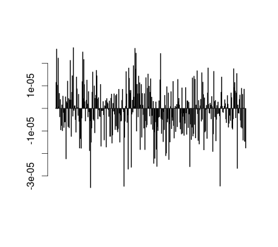

Powyższy opis ilustruje drzewo decyzyjne:

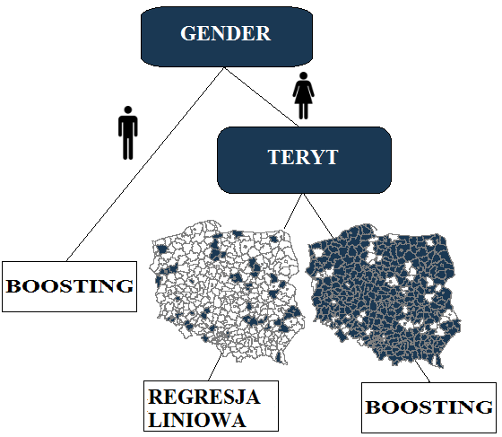

# Prezentacja wyników

Na poniższych kartogramach prezentujemy predykcję na rok 2013 odsetka zachorowań z podziałem na płeć:

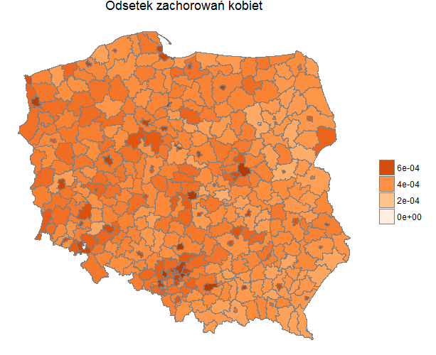

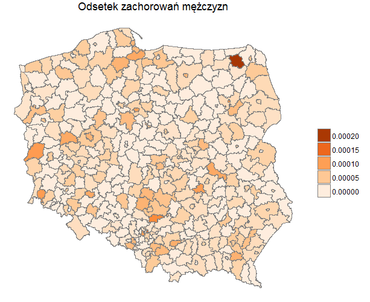

# Podsumowanie

Na podstawie testu t oraz liniowej korelacji Pearsona spośród zgromadzonych czynników jako najistotniejsze wybraliśmy następujące: gęstość zaludnienia, urbanizację, wiek, poziom spożycia alkoholu wśród kobiet oraz liczbę osób zarejestrowanych w poradniach psychologicznych. Przetestowanie mocy predykcyjnej modeli wskazało, iż najlepiej radzi sobie gradient boosting z selekcją atrybutów, gradient boosting oraz model liniowy z zestawem zmiennych wybranych na podstawie kryterium BIC. W oparciu o analizę błędów, ostatecznie zdecydowaliśmy się na zastosowanie modelu *“mieszanego”*, który składa się z **gradient boostingu oraz regresji liniowej**.